← Voltar ao Portal

[figure not shown]

Programa 411

# Síntese Avaliativa do Desempenho dos Programas do PPA Bahia 2024–2027

# **1 - Desempenho Global do Programa**

Este documento apresenta uma Síntese Avaliativa do Desempenho do Programa do Plano Plurianual - PPA 2024- 2027, trazendo uma visão estratégica dos seus resultados, de forma sintética, transparente e colaborativa. Serão levados em consideração o Indicador Sintético de Desempenho do Programa (ISDP), a evolução dos Indicadores de Programa, a eficácia das metas dos Indicadores de Compromisso, o desempenho da execução orçamentária-financeira e da execução física das Ações orçamentárias. O ISDP é uma síntese dessas quatro dimensões, destacando o desempenho do programa em relação aos resultados obtidos e aos esforços despendidos.  
Adicionalmente, são apresentados os principais resultados alcançados, evidenciando os avanços e conformidades dos cinco programas com melhores resultados, além das oportunidades de melhoria dos cinco, com menores resultados. Enquanto neste documento a análise abrange o programa e seus componentes de maneira sintética, nos demais relatórios, a análise detalhada evidencia o comportamento dos componentes do PPA por programas e por órgãos (https://www.ba.gov.br/seplan/monitoramento-e-avaliacao/avaliacao-do-ppa). Além desta Síntese, o [Painel BI - Boletim de Avanços e Oportunidades de Melhoria](https://app.powerbi.com/view?r=eyJrIjoiN2Q0ODliNDItZDFjZi00MGM1LTliNGEtODVmZDAwZTQ1OGEyIiwidCI6IjRjZDgzNWY0LTU0NDAtNDA4Zi05M2EzLTk3NWZjMTdjMzg0YSIsImMiOjR9) oferece informações organizadas em uma perspectiva estratégica do desempenho consolidado dos programas, detalhando, no entanto, cada componente avaliado. A análise nesta seção engloba o programa e seus componentes conforme segue:

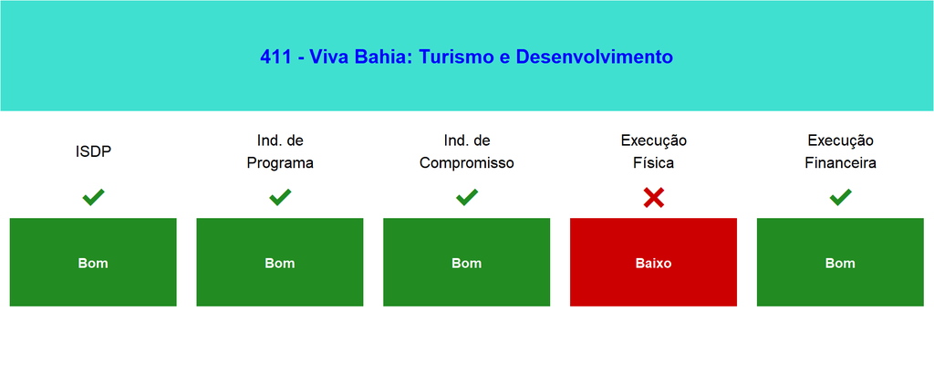

# **2 - Avanços e Conformidades no Programa**

**Indicadores de Programa:** No programa 411 - Viva Bahia: Turismo e Desenvolvimento, 75% dos indicadores mostraram evolução positiva. O indicador 2194, que trata do estoque de emprego formal no setor de turismo, apresentou um aumento de 20,82%, resultado da ampliação dos serviços e do aumento da demanda turística no estado.  
**Indicadores de Compromisso:** No programa 411 - Viva Bahia: Turismo e Desenvolvimento, 59% dos indicadores de compromisso foram classificados como de desempenho bom ou ótimo. Entre eles, destaca-se o indicador ‘2 - Número de planos de trabalho para Câmaras Técnicas elaborados’, que atingiu a marca de 100%. Contudo, é importante ressaltar que, em decorrência da alta demanda do setor responsável em 2025, houve um atraso na entrega de alguns planos, situação que será regularizada em 2026. Outro indicador relevante é o ‘3 - Número de roteiros formatados e promovidos’, que também alcançou 100%, resultado da eficiência e dedicação da equipe, que superou a meta estabelecida.  
**Ações Orçamentárias:** No tocante ao Programa 411 - Viva Bahia: Turismo e Desenvolvimento, 85% das ações foram classificadas com desempenho bom ou ótimo na execução financeira, enquanto 33,4% obtiveram essa classificação na execução física. Um exemplo é a Ação 5483 - Elaboração de Instrumento de Planejamento, Pesquisas e Diagnósticos na Área de Turismo, que apresentou resultados ótimos, assim como a Ação 3210 - Implantação de Roteiro Turístico, que mostrou desempenho semelhante.

# **3 - Oportunidade de Melhoria no Programa**

**Indicadores de Programa:** No programa 411 - Viva Bahia: Turismo e Desenvolvimento, também 25% dos indicadores mostraram evolução negativa. O indicador 02192, que avalia a variação do consumo de energia elétrica (kWh) nas Atividades Características do Turismo (ACTs), apresentou uma diminuição de 1475%. Essa redução pode ser explicada pelo aumento da sustentabilidade no setor de turismo e pela adoção de fontes alternativas de energia, como solar e eólica. Contudo, outros indicadores, como o número de turistas internacionais que chegam à Bahia por vias aérea e marítima, além do fluxo de passageiros nos principais aeroportos, demonstram um crescimento no turismo.  
**Indicadores de Compromisso:** No programa 411 - Viva Bahia: Turismo e Desenvolvimento, 9% dos indicadores foram classificados como de desempenho baixo, com 4,5% indeterminados e 18,2% não aptos para avaliação. O indicador ‘Número de ações de promoção do Turismo de Base Comunitária’ obteve apenas 16,7%. Isso se relaciona à elaboração de plano de ação e oficinas de orientação. Para o indicador sobre equipamentos turísticos implantados, que conseguiu 33,3%, o atraso na licitação de um equipamento esperado dificultou o atingimento completo da meta.  
**Ações Orçamentárias:** No entanto, no Programa 411 - Viva Bahia: Turismo e Desenvolvimento, 15% das ações apresentaram desempenho baixo ou muito baixo na execução financeira, com 66,6% na execução física. A ação 5490 - Implantação de Sinalização Turística teve desempenho financeiro classificado como “Baixo” e físico como “Muito Baixo”, enquanto a ação 5489 - Implantação de Infraestrutura Turística apresentou ambos os desempenhos como “Muito Baixo”.

Desenvolvido por: DAP – Diretoria de Avaliação de Políticas Públicas